# Experiment3: More Airline Data

Asynchronous lecture

2023-09-11

# Packages

```r
library(tidyverse)
library(nycflights13)
library(here)
library(janitor)
```

```r
library(ggplot2)
```

# Get data from the online source.

Save the download to your data_raw directory. It will be a zipfile,, but that will be OK. Don’t change the name of the zipfile.

## Load the BOT data

We take advantage of the ‘here’ package to get the path to the file that we stored. We also may note that inside the zipfile is a csv file. We will read the csvfile.

```r
thisfile <- here("data_raw", "DL_SelectFields.zip")

df2022 <- read_csv(thisfile) |> clean_names()
```

## Subsetting to data of interesst

Let’s focus on flights from La Guardia (airport “LGA”) and eliminate cargo flights by requiring at least 1 passanger.

Call the resultant dataframe ‘df9’

```r
df9 <- df2022 |> filter(passengers > 0, origin == "LGA")
```

# Exploring the BOT 2022 data

## Subsetting to data of interest

Let’s try to visualize a monthly count of flights using a barchart.

First a not quite right visualization

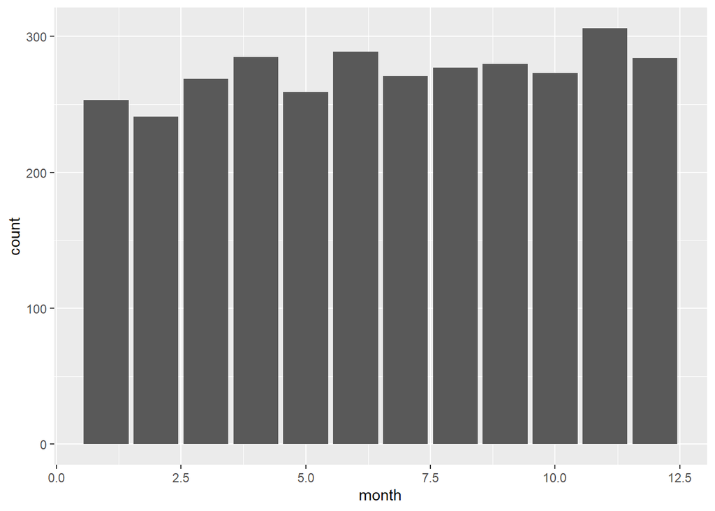

```r
df9 |>
  ggplot((aes(month))) + geom_bar()
```

By default, ‘geom_bar’ is counting the number of rows, where we have asked it to visualize the count by ‘month’.

** Take a look at the dataset and discover why counting rows is not going to give us a count of filghts. **

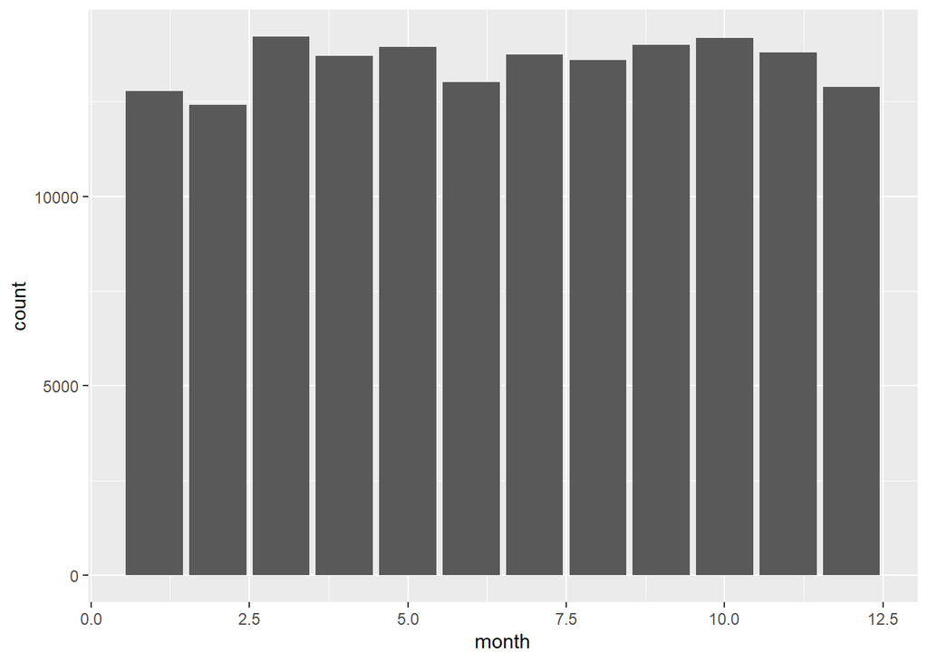

```r
df9 |>
  ggplot (aes(month)) + geom_bar(aes(weight = departures_performed))
```

Make some observations about this plot.

Observation:

Can you make boxplot where the bar height is based on the number of passengers riding each month?

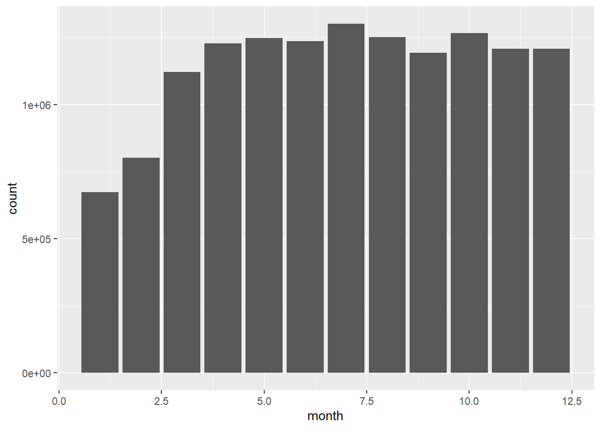

```r
df9 |>
  ggplot (aes(month)) + geom_bar(aes(weight = passengers))
```

Observation:

- low passenger numbers in early 2022 likely due to covid.
- It makes sense that July had the largest amount of passengers because it is a usual vacation month.

## Just because you can

Here is pretty, but not so useful plot.

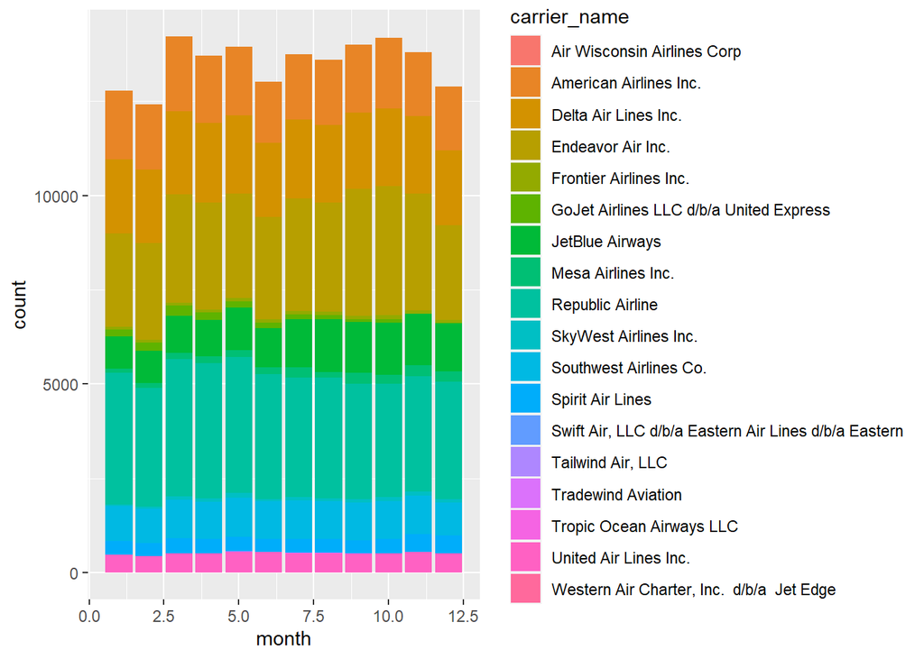

```r
df9 |>
  ggplot (aes(month, fill = carrier_name)) + geom_bar(aes(weight = departures_performed))
```

## Arrivals and departures from LGA

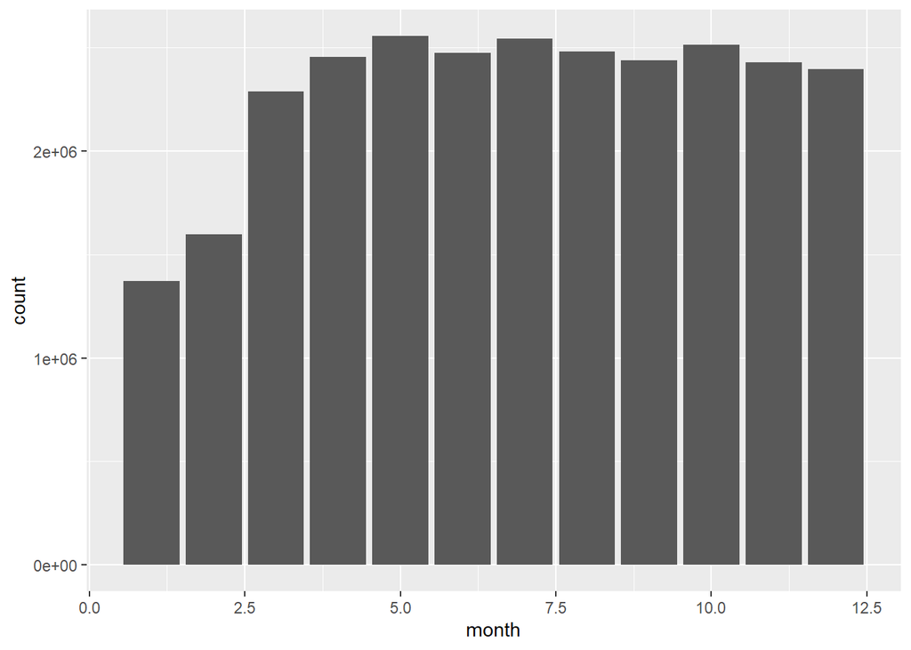

```r
df10 <- df2022 |> filter(passengers > 0, origin == "LGA" | dest == "LGA")

df10 |> ggplot(aes(month)) + geom_bar(aes(weight = passengers))
```

```r
df11 <- df10 |>
  select(month, passengers, seats, carrier_name,dest, origin)
```

```r
df12 <- df10 |> select(1:5, month, contains("id"))
```

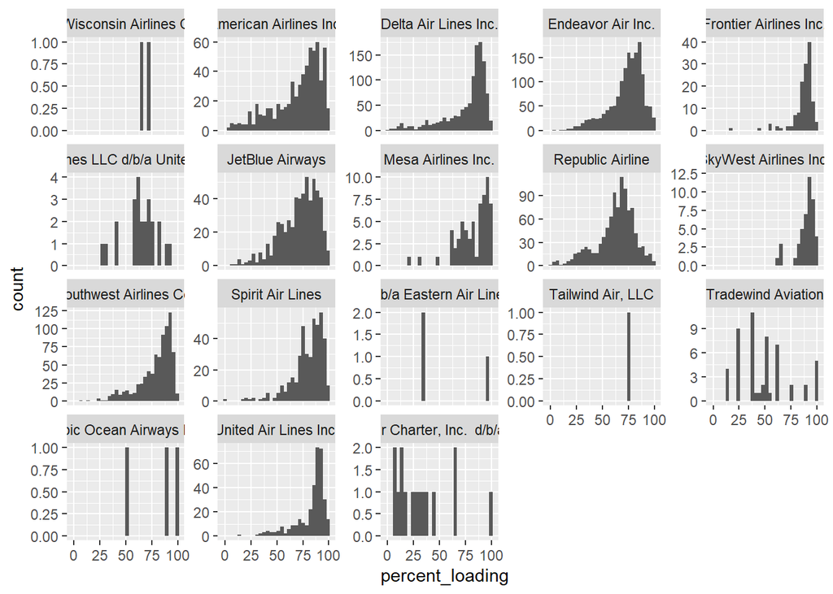

```r
df13 <- df11 |> mutate(percent_loading = passengers / seats * 100)

df13 |> ggplot(aes(percent_loading)) +
  geom_histogram() + facet_wrap(~carrier_name, scales = "free_y")
```